# Differential gene abundance report

differentialabundance workflow versionv1.5.0-g3dd360f

2026-06-03

# Abstract

This report summarises differential gene analysis as performed by the nf-core/differentialabundance pipeline.

# Data

## Samples

A summary of sample metadata is below:

| Sample | Condition | Replicate | Batch |
| --- | --- | --- | --- |
| C2M_R1 | mutant_c2m | 1 | A |
| C2M_R2 | mutant_c2m | 2 | A |
| C2M_R3 | mutant_c2m | 3 | A |
| Sfmbt_R1 | mutant_sfmbt | 1 | A |
| Sfmbt_R2 | mutant_sfmbt | 2 | A |
| Sfmbt_R3 | mutant_sfmbt | 3 | A |
| C2M_Sfmbt_R1 | mutant_c2mSfmbt | 1 | A |
| C2M_Sfmbt_R2 | mutant_c2mSfmbt | 2 | A |
| C2M_Sfmbt_R3 | mutant_c2mSfmbt | 3 | A |
| control_R1 | control | 1 | A |

[output cut: 2 more lines]

## Contrasts

Comparisons were made between sample groups defined using metadata columns, as described in the following table of contrasts:

| Id | Variable | Reference | Target | Blocking | model |
| --- | --- | --- | --- | --- | --- |
| sfmbti | condition | control | mutant_sfmbt |  | ~ 0 + condition |
| C2Moe | condition | control | mutant_c2m |  | ~ 0 + condition |
| sfmbti_c2mOe | condition | control | mutant_c2mSfmbt |  | ~ 0 + condition |
| both_v_sfmbt | condition | mutant_sfmbt | mutant_c2mSfmbt |  | ~ 0 + condition |

# Results

## Counts

Input was a matrix of 16727 genes for 12 samples, reduced to 14203 genes after filtering for low abundance.

## Exploratory analysis

### Abundance value distributions

The following plots show the abundance value distributions of input matrices. A log2 transformation is applied where not already performed.

#### Box plots

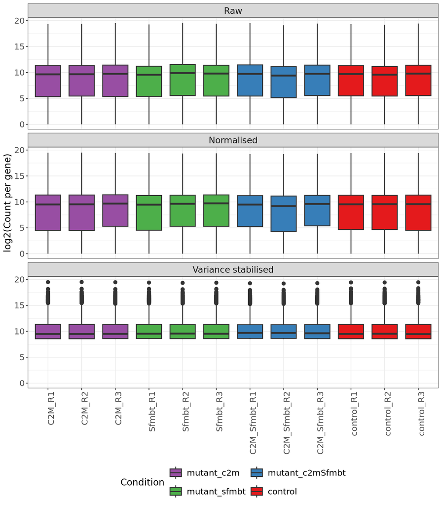

Whiskers in the above boxplots show 1.5 times the inter-quartile range.

#### Density plots

[interactive chart not shown]

### Sample relationships

#### Principal components plots

Principal components analysis was conducted based on the 500 most variable genes. Each component was annotated with its percent contribution to variance.

##### Variance stabilised (condition)

[interactive chart not shown]

##### Normalised (condition)

[interactive chart not shown]

##### Raw (condition)

[interactive chart not shown]

#### Scree plot

The following scree plot visualizes what percentage of total variation in the data can be explained by each of the principal components computed.

##### Variance stabilised

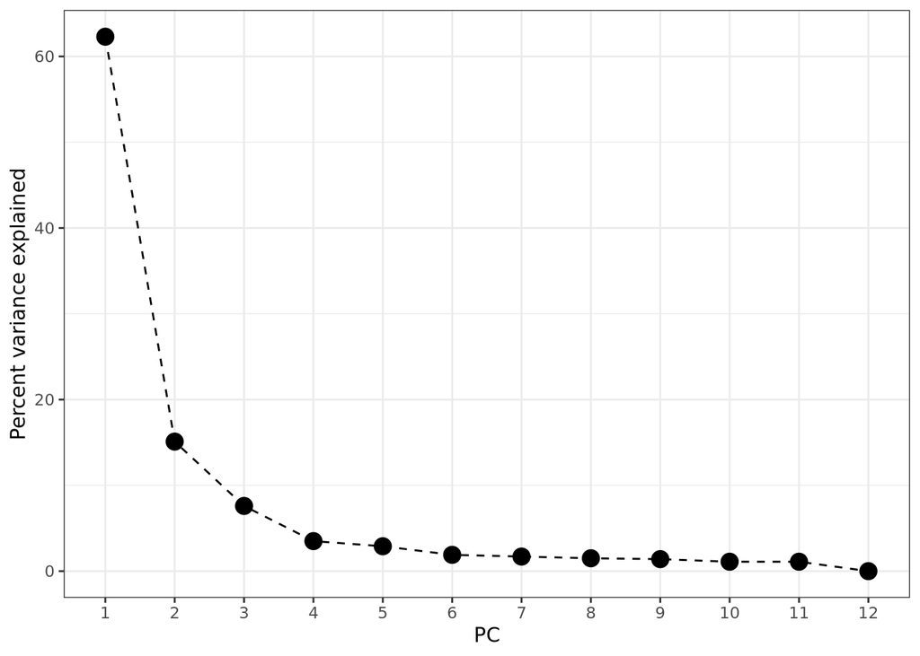

##### Normalised

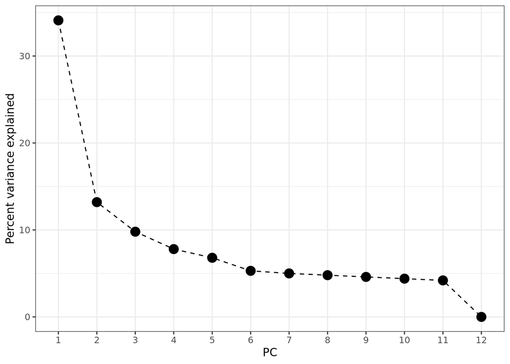

##### Raw

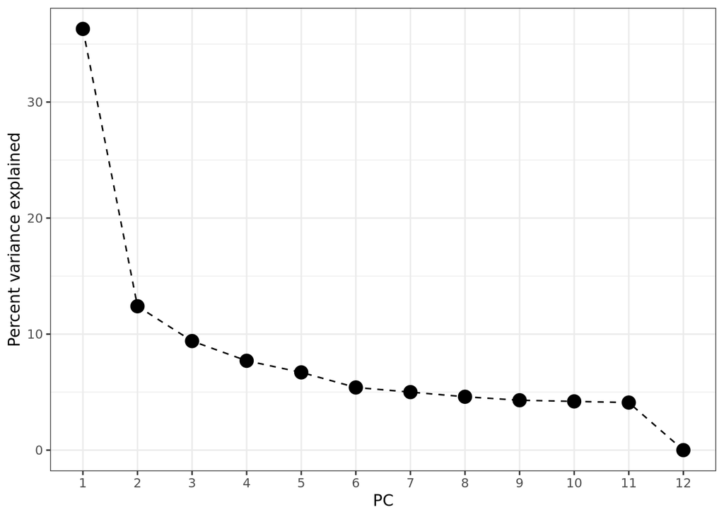

#### Principal components/ metadata associations

For the variance stabilised matrix, an ANOVA test was used to determine assocations between continuous principal components and categorical covariates (including the variable of interest).

The resulting p values are illustrated below.

[interactive chart not shown]

The variable ‘condition’ shows an association with PC1 (62.3%) (p = 0.00).

#### Clustering dendrograms

##### Variance stabilised (condition)

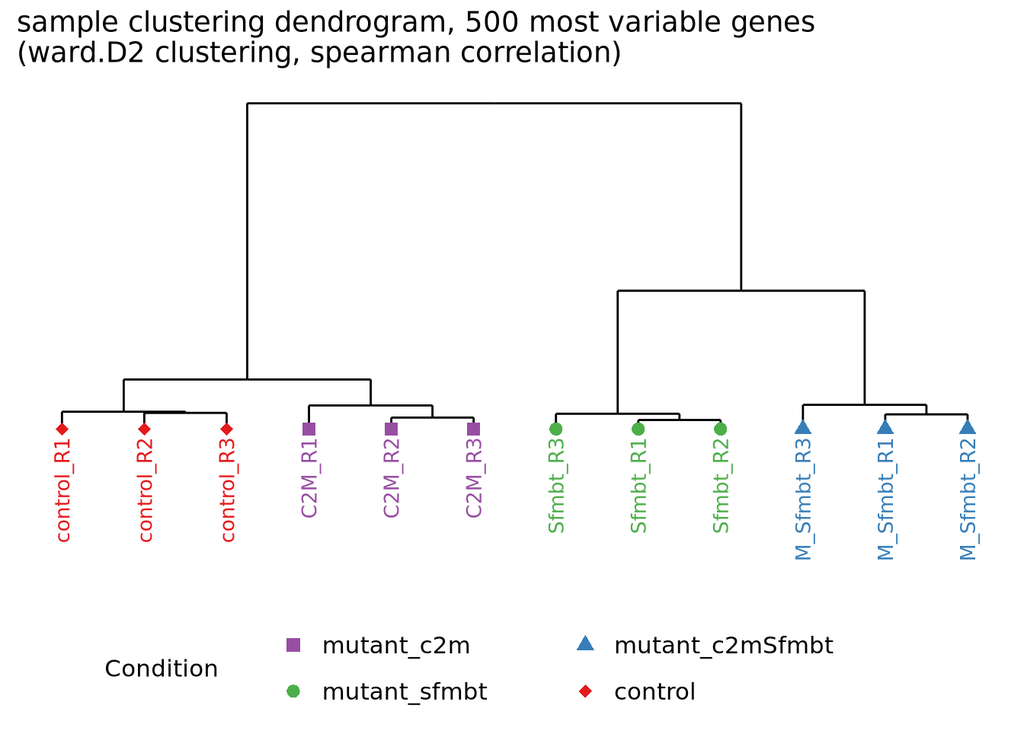

##### Normalised (condition)

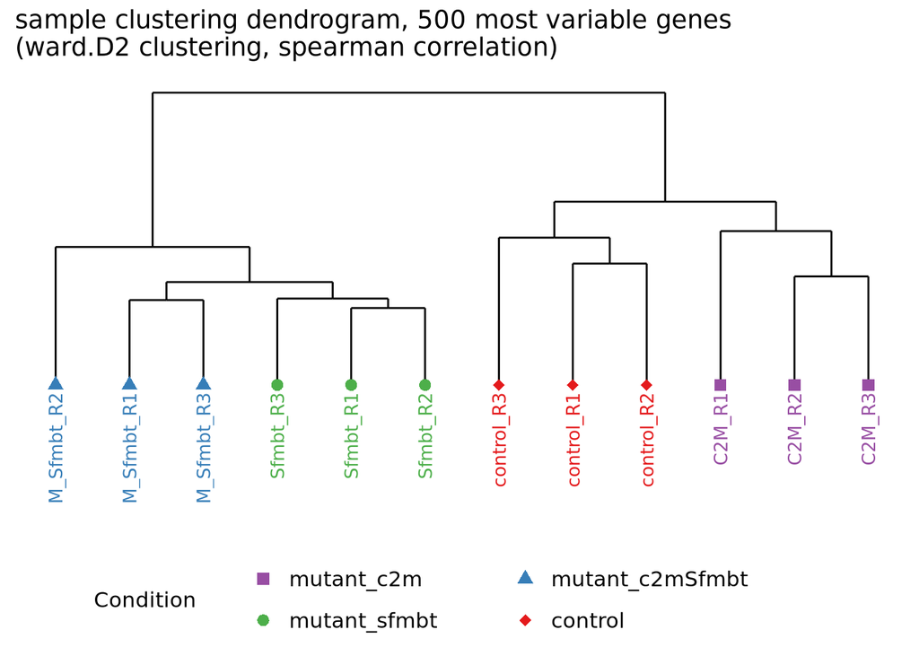

##### Raw (condition)

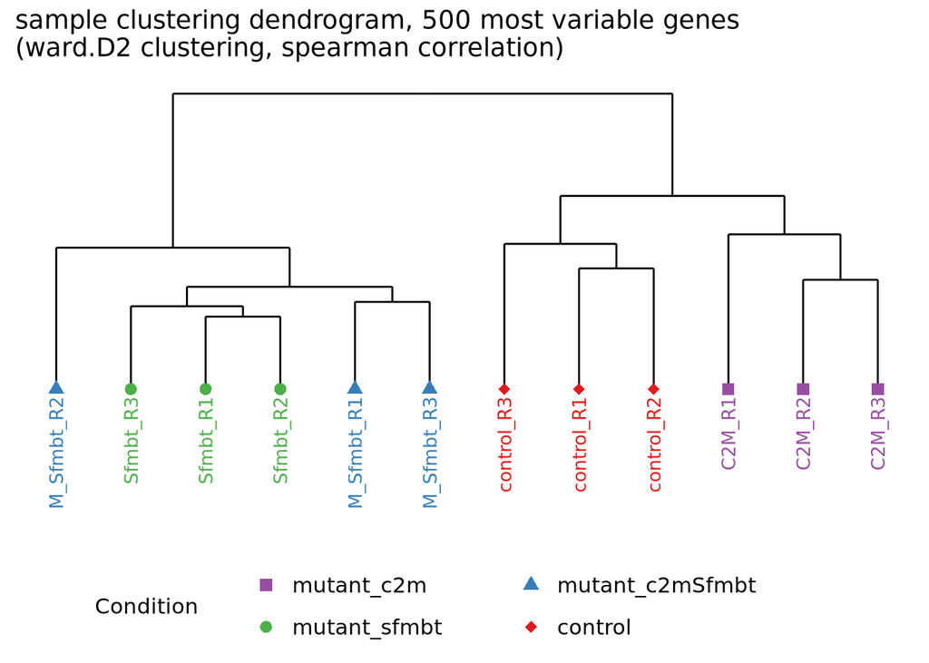

### Outlier detection

Outlier detection based on [median absolute deviation](https://wiki.arrayserver.com/wiki/index.php?title=CorrelationQC.pdf) was undertaken, the outlier scoring is plotted below.

#### condition

[interactive chart not shown]

1 possible outliers were detected in groups defined by condition: C2M_R1

## Differential analysis

### Differential gene counts

#### Adjusted

|  | up | down |
| --- | --- | --- |
| mutant_sfmbt versus control in condition | [242] | [66] |
| mutant_c2m versus control in condition | [69] | [67] |
| mutant_c2mSfmbt versus control in condition | [698] | [219] |
| mutant_c2mSfmbt versus mutant_sfmbt in condition | [432] | [64] |

#### Unadjusted

|  | up | down |
| --- | --- | --- |
| mutant_sfmbt versus control in condition | [242] | [66] |
| mutant_c2m versus control in condition | [69] | [67] |
| mutant_c2mSfmbt versus control in condition | [698] | [219] |
| mutant_c2mSfmbt versus mutant_sfmbt in condition | [432] | [64] |

### Differential gene details

#### mutant_sfmbt versus control in condition

##### Adjusted p values

*6 features are not shown because of p value = 0; please refer to the results tables.*

[interactive chart not shown]

| Gene id | Pvalue | Padj | Log2FoldChange |
| --- | --- | --- | --- |
| Actbeta | 2.25e-07 | 3.201e-06 | 2.088 |
| Ada1-1 | 0.002626 | 0.01357 | 1.256 |
| aly | 1.256e-21 | 7.156e-20 | 4.557 |
| BBS4 | 0.0007323 | 0.004581 | 1.802 |
| betaNACtes3 | 2.673e-12 | 7.554e-11 | 5.789 |
| betaNACtes6 | 3.928e-08 | 6.379e-07 | 6.435 |
| bgcn | 1.761e-90 | 5.625e-88 | 2.784 |
| blanks | 1.865e-61 | 3.709e-59 | 3.95 |
| c(3)G | 4.123e-105 | 1.739e-102 | 1.403 |
| CG10013 | 3.108e-190 | 3.276e-187 | 3.836 |

[output cut: 232 more lines]

| Gene id | Pvalue | Padj | Log2FoldChange |
| --- | --- | --- | --- |
| alpha-Est1 | 2.411e-42 | 3.217e-40 | -1.37 |
| Arc1 | 8.006e-59 | 1.534e-56 | -1.236 |
| BicC | 1.924e-35 | 2.028e-33 | -1.252 |
| CG11034 | 3.744e-64 | 8.221e-62 | -2.192 |
| CG12721 | 1.008e-73 | 2.656e-71 | -2.329 |
| CG12947 | 7.64e-10 | 1.579e-08 | -1.149 |
| CG13912 | 3.286e-22 | 1.924e-20 | -3.821 |
| CG15236 | 2.77e-07 | 3.847e-06 | -1.468 |
| CG15820 | 1.019e-21 | 5.84e-20 | -1.121 |
| CG1665 | 5.518e-35 | 5.647e-33 | -1.01 |

[output cut: 56 more lines]

##### Unadjusted p values

*6 features are not shown because of p value = 0; please refer to the results tables.*

[interactive chart not shown]

| Gene id | Pvalue | Padj | Log2FoldChange |
| --- | --- | --- | --- |
| Actbeta | 2.25e-07 | 3.201e-06 | 2.088 |
| Ada1-1 | 0.002626 | 0.01357 | 1.256 |
| aly | 1.256e-21 | 7.156e-20 | 4.557 |
| BBS4 | 0.0007323 | 0.004581 | 1.802 |
| betaNACtes3 | 2.673e-12 | 7.554e-11 | 5.789 |
| betaNACtes6 | 3.928e-08 | 6.379e-07 | 6.435 |
| bgcn | 1.761e-90 | 5.625e-88 | 2.784 |
| blanks | 1.865e-61 | 3.709e-59 | 3.95 |
| c(3)G | 4.123e-105 | 1.739e-102 | 1.403 |
| CG10013 | 3.108e-190 | 3.276e-187 | 3.836 |

[output cut: 232 more lines]

| Gene id | Pvalue | Padj | Log2FoldChange |
| --- | --- | --- | --- |
| alpha-Est1 | 2.411e-42 | 3.217e-40 | -1.37 |
| Arc1 | 8.006e-59 | 1.534e-56 | -1.236 |
| BicC | 1.924e-35 | 2.028e-33 | -1.252 |
| CG11034 | 3.744e-64 | 8.221e-62 | -2.192 |
| CG12721 | 1.008e-73 | 2.656e-71 | -2.329 |
| CG12947 | 7.64e-10 | 1.579e-08 | -1.149 |
| CG13912 | 3.286e-22 | 1.924e-20 | -3.821 |
| CG15236 | 2.77e-07 | 3.847e-06 | -1.468 |
| CG15820 | 1.019e-21 | 5.84e-20 | -1.121 |
| CG1665 | 5.518e-35 | 5.647e-33 | -1.01 |

[output cut: 56 more lines]

#### mutant_c2m versus control in condition

##### Adjusted p values

[interactive chart not shown]

| Gene id | Pvalue | Padj | Log2FoldChange |
| --- | --- | --- | --- |
| Ace | 4.65e-11 | 4.504e-09 | 1.383 |
| c(2)M | 7.538e-135 | 2.58e-131 | 4.142 |
| Cda5 | 1.889e-06 | 7.664e-05 | 1.505 |
| CG10962 | 1.925e-18 | 4.392e-16 | 1.367 |
| CG11069 | 9.71e-12 | 1.007e-09 | 1.185 |
| CG11453 | 2.122e-07 | 1.158e-05 | 2.257 |
| CG11638 | 5.148e-21 | 1.321e-18 | 1.133 |
| CG12592 | 1.25e-49 | 1.167e-46 | 1.365 |
| CG13114 | 7.292e-08 | 4.352e-06 | 3.454 |
| CG13362 | 7.816e-07 | 3.664e-05 | 2.465 |

[output cut: 59 more lines]

| Gene id | Pvalue | Padj | Log2FoldChange |
| --- | --- | --- | --- |
| Arc1 | 4.61e-105 | 1.183e-101 | -1.685 |
| Cda4 | 1.969e-24 | 6.737e-22 | -4.498 |
| CG12061 | 2.128e-05 | 0.0006315 | -2.096 |
| CG12522 | 1.732e-09 | 1.358e-07 | -6.933 |
| CG13068 | 4.254e-06 | 0.0001527 | -1.243 |
| CG13609 | 1.046e-17 | 2.148e-15 | -2.387 |
| CG13678 | 0.0003175 | 0.005722 | -1.247 |
| CG13793 | 4.804e-17 | 9.485e-15 | -2.575 |
| CG13982 | 5.806e-05 | 0.001446 | -1.726 |
| CG14410 | 2.222e-06 | 8.808e-05 | -1.475 |

[output cut: 57 more lines]

##### Unadjusted p values

[interactive chart not shown]

| Gene id | Pvalue | Padj | Log2FoldChange |
| --- | --- | --- | --- |
| Ace | 4.65e-11 | 4.504e-09 | 1.383 |
| c(2)M | 7.538e-135 | 2.58e-131 | 4.142 |
| Cda5 | 1.889e-06 | 7.664e-05 | 1.505 |
| CG10962 | 1.925e-18 | 4.392e-16 | 1.367 |
| CG11069 | 9.71e-12 | 1.007e-09 | 1.185 |
| CG11453 | 2.122e-07 | 1.158e-05 | 2.257 |
| CG11638 | 5.148e-21 | 1.321e-18 | 1.133 |
| CG12592 | 1.25e-49 | 1.167e-46 | 1.365 |
| CG13114 | 7.292e-08 | 4.352e-06 | 3.454 |
| CG13362 | 7.816e-07 | 3.664e-05 | 2.465 |

[output cut: 59 more lines]

| Gene id | Pvalue | Padj | Log2FoldChange |
| --- | --- | --- | --- |
| Arc1 | 4.61e-105 | 1.183e-101 | -1.685 |
| Cda4 | 1.969e-24 | 6.737e-22 | -4.498 |
| CG12061 | 2.128e-05 | 0.0006315 | -2.096 |
| CG12522 | 1.732e-09 | 1.358e-07 | -6.933 |
| CG13068 | 4.254e-06 | 0.0001527 | -1.243 |
| CG13609 | 1.046e-17 | 2.148e-15 | -2.387 |
| CG13678 | 0.0003175 | 0.005722 | -1.247 |
| CG13793 | 4.804e-17 | 9.485e-15 | -2.575 |
| CG13982 | 5.806e-05 | 0.001446 | -1.726 |
| CG14410 | 2.222e-06 | 8.808e-05 | -1.475 |

[output cut: 57 more lines]

#### mutant_c2mSfmbt versus control in condition

##### Adjusted p values

*4 features are not shown because of p value = 0; please refer to the results tables.*

[interactive chart not shown]

| Gene id | Pvalue | Padj | Log2FoldChange |
| --- | --- | --- | --- |
| 5-HT1A | 4.433e-07 | 2.25e-06 | 1.172 |
| abd-A | 5.77e-12 | 5.426e-11 | 1.049 |
| Abd-B | 1.946e-06 | 8.901e-06 | 1.145 |
| Act88F | 6.354e-05 | 0.0002314 | 1.862 |
| Actbeta | 2.083e-05 | 8.203e-05 | 1.484 |
| Adgf-C | 7.417e-08 | 4.224e-07 | 1.081 |
| alphaTry | 0.001204 | 0.003413 | 1.665 |
| aly | 5.195e-15 | 6.632e-14 | 3.704 |
| Ance | 7.934e-22 | 1.753e-20 | 1.61 |
| Ance-5 | 5.74e-15 | 7.296e-14 | 1.664 |

[output cut: 688 more lines]

| Gene id | Pvalue | Padj | Log2FoldChange |
| --- | --- | --- | --- |
| 26-29-p | 2.54e-33 | 1.045e-31 | -1.029 |
| AcCoAS | 1.852e-32 | 7.261e-31 | -1.483 |
| Acox57D-d | 2.04e-37 | 1.006e-35 | -1.085 |
| Acox57D-p | 4.356e-21 | 9.171e-20 | -1.032 |
| Acph-1 | 1.29e-39 | 6.793e-38 | -1.021 |
| alpha-Est1 | 2.996e-114 | 1.026e-111 | -2.357 |
| alpha-Est5 | 2.516e-41 | 1.429e-39 | -1.162 |
| alphaTub67C | 1.112e-49 | 8.928e-48 | -1.143 |
| APC7 | 7.74e-97 | 1.917e-94 | -1.787 |
| Arc1 | 3.029e-205 | 3.205e-202 | -2.386 |

[output cut: 209 more lines]

##### Unadjusted p values

*4 features are not shown because of p value = 0; please refer to the results tables.*

[interactive chart not shown]

| Gene id | Pvalue | Padj | Log2FoldChange |
| --- | --- | --- | --- |
| 5-HT1A | 4.433e-07 | 2.25e-06 | 1.172 |
| abd-A | 5.77e-12 | 5.426e-11 | 1.049 |
| Abd-B | 1.946e-06 | 8.901e-06 | 1.145 |
| Act88F | 6.354e-05 | 0.0002314 | 1.862 |
| Actbeta | 2.083e-05 | 8.203e-05 | 1.484 |
| Adgf-C | 7.417e-08 | 4.224e-07 | 1.081 |
| alphaTry | 0.001204 | 0.003413 | 1.665 |
| aly | 5.195e-15 | 6.632e-14 | 3.704 |
| Ance | 7.934e-22 | 1.753e-20 | 1.61 |
| Ance-5 | 5.74e-15 | 7.296e-14 | 1.664 |

[output cut: 688 more lines]

| Gene id | Pvalue | Padj | Log2FoldChange |
| --- | --- | --- | --- |
| 26-29-p | 2.54e-33 | 1.045e-31 | -1.029 |
| AcCoAS | 1.852e-32 | 7.261e-31 | -1.483 |
| Acox57D-d | 2.04e-37 | 1.006e-35 | -1.085 |
| Acox57D-p | 4.356e-21 | 9.171e-20 | -1.032 |
| Acph-1 | 1.29e-39 | 6.793e-38 | -1.021 |
| alpha-Est1 | 2.996e-114 | 1.026e-111 | -2.357 |
| alpha-Est5 | 2.516e-41 | 1.429e-39 | -1.162 |
| alphaTub67C | 1.112e-49 | 8.928e-48 | -1.143 |
| APC7 | 7.74e-97 | 1.917e-94 | -1.787 |
| Arc1 | 3.029e-205 | 3.205e-202 | -2.386 |

[output cut: 209 more lines]

#### mutant_c2mSfmbt versus mutant_sfmbt in condition

##### Adjusted p values

*1 feature is not shown because of p value = 0; please refer to the results tables.*

[interactive chart not shown]

| Gene id | Pvalue | Padj | Log2FoldChange |
| --- | --- | --- | --- |
| 5-HT1A | 6.057e-13 | 1.71e-11 | 1.755 |
| abd-A | 1.506e-13 | 4.667e-12 | 1.127 |
| Ac76E | 4.445e-12 | 1.078e-10 | 1.068 |
| Adgf-C | 6.862e-11 | 1.323e-09 | 1.329 |
| AdoR | 2.095e-09 | 3.074e-08 | 1.152 |
| alpha-Est8 | 1.011e-07 | 1.047e-06 | 1.284 |
| alphaTry | 1.32e-05 | 8.179e-05 | 2.763 |
| Ance | 3.543e-19 | 2.599e-17 | 1.469 |
| Ance-5 | 1.573e-10 | 2.86e-09 | 1.3 |
| aos | 6.779e-16 | 2.944e-14 | 1.14 |

[output cut: 422 more lines]

| Gene id | Pvalue | Padj | Log2FoldChange |
| --- | --- | --- | --- |
| Appl | 4.722e-19 | 3.383e-17 | -1.448 |
| Arc1 | 8.229e-48 | 4.45e-45 | -1.133 |
| bw | 0.0003629 | 0.00157 | -1.293 |
| CG10013 | 2.527e-26 | 3.693e-24 | -1.121 |
| CG11263 | 1.379e-28 | 2.485e-26 | -1.215 |
| CG11843 | 3.034e-06 | 2.205e-05 | -1.617 |
| CG12061 | 6.421e-06 | 4.309e-05 | -1.561 |
| CG13029 | 1.623e-08 | 2.008e-07 | -1.327 |
| CG13313 | 1.354e-05 | 8.373e-05 | -1.254 |
| CG13397 | 1.293e-140 | 3.762e-137 | -2.749 |

[output cut: 54 more lines]

##### Unadjusted p values

*1 feature is not shown because of p value = 0; please refer to the results tables.*

[interactive chart not shown]

| Gene id | Pvalue | Padj | Log2FoldChange |
| --- | --- | --- | --- |
| 5-HT1A | 6.057e-13 | 1.71e-11 | 1.755 |
| abd-A | 1.506e-13 | 4.667e-12 | 1.127 |
| Ac76E | 4.445e-12 | 1.078e-10 | 1.068 |
| Adgf-C | 6.862e-11 | 1.323e-09 | 1.329 |
| AdoR | 2.095e-09 | 3.074e-08 | 1.152 |
| alpha-Est8 | 1.011e-07 | 1.047e-06 | 1.284 |
| alphaTry | 1.32e-05 | 8.179e-05 | 2.763 |
| Ance | 3.543e-19 | 2.599e-17 | 1.469 |
| Ance-5 | 1.573e-10 | 2.86e-09 | 1.3 |
| aos | 6.779e-16 | 2.944e-14 | 1.14 |

[output cut: 422 more lines]

| Gene id | Pvalue | Padj | Log2FoldChange |
| --- | --- | --- | --- |
| Appl | 4.722e-19 | 3.383e-17 | -1.448 |
| Arc1 | 8.229e-48 | 4.45e-45 | -1.133 |
| bw | 0.0003629 | 0.00157 | -1.293 |
| CG10013 | 2.527e-26 | 3.693e-24 | -1.121 |
| CG11263 | 1.379e-28 | 2.485e-26 | -1.215 |
| CG11843 | 3.034e-06 | 2.205e-05 | -1.617 |
| CG12061 | 6.421e-06 | 4.309e-05 | -1.561 |
| CG13029 | 1.623e-08 | 2.008e-07 | -1.327 |
| CG13313 | 1.354e-05 | 8.373e-05 | -1.254 |
| CG13397 | 1.293e-140 | 3.762e-137 | -2.749 |

[output cut: 54 more lines]

# Methods

## Filtering

| Parameter | Value |
| --- | --- |
| min_samples | 1 |
| min_abundance | 1 |
| min_proportion_not_na | 0.5 |

## Exploratory analysis

| Parameter | Value |
| --- | --- |
| log2_assays | raw,normalised |
| n_features | 500 |
| clustering_method | ward.D2 |
| cor_method | spearman |
| whisker_distance | 1.5 |
| mad_threshold | -5 |
| main_variable | auto_pca |
| assay_names | raw,normalised,variance_stabilised |
| final_assay | variance_stabilised |
| palette_name | Set1 |

## Differential analysis

| Parameter | Value |
| --- | --- |
| test | Wald |
| fit_type | parametric |
| sf_type | ratio |
| min_replicates_for_replace | 7 |
| use_t | FALSE |
| lfc_threshold | 0 |
| alt_hypothesis | greaterAbs |
| independent_filtering | TRUE |
| p_adjust_method | BH |
| alpha | 0.1 |

[output cut: 6 more lines]

| Parameter | Value |
| --- | --- |
| table | file.csv |
| feature_id_column | gene_id |
| feature_name_column | gene_name |
| fc_column | log2FoldChange |
| pval_column | pvalue |
| qval_column | padj |
| min_fold_change | 2 |
| foldchanges_logged | TRUE |
| max_pval | 1 |
| max_qval | 0.05 |

[output cut: 2 more lines]

# Appendices

## All parameters

| Parameter | Value |
| --- | --- |
| meta.id | study |
| input_dir | ./ |
| artifact_dir | artifacts |
| cpus | 2 |
| study_type | rnaseq |
| study_name | study |
| study_abundance_type | counts |
| report_file | /home/j88c776/.nextflow/assets/nf-core/differentialabundance/assets/differentialabundance_report.Rmd |
| report_scree | TRUE |
| report_round_digits | 4 |

[output cut: 61 more lines]

## Software versions

**Note:** For a more detailed accounting of the software and commands used (including containers), consult the execution report produced as part of the ‘pipeline info’ for this workflow.

| Component | Software | Version |
| --- | --- | --- |
| DESEQ2_DIFFERENTIAL | r-base | 4.1.3 |
| DESEQ2_DIFFERENTIAL | bioconductor-deseq2 | 1.34.0 |
| PLOT_DIFFERENTIAL | r-base | 4.3.3 |
| PLOT_DIFFERENTIAL | r-shinyngs | 1.8.8 |
| PLOT_EXPLORATORY | r-shinyngs | 1.8.8 |
| VALIDATOR | r-base | 4.3.3 |
| VALIDATOR | r-shinyngs | 1.8.8 |
| Workflow | nf-core/differentialabundance | v1.5.0-g3dd360f |
| Workflow | Nextflow | 23.10.0 |

# nf-core/differentialabundance: Citations

## [nf-core](https://pubmed.ncbi.nlm.nih.gov/32055031/)

> Ewels PA, Peltzer A, Fillinger S, Patel H, Alneberg J, Wilm A, Garcia MU, Di Tommaso P, Nahnsen S. The nf-core framework for community-curated bioinformatics pipelines. Nat Biotechnol. 2020 Mar;38(3):276-278. doi: 10.1038/s41587-020-0439-x. PubMed PMID: 32055031.

## [Nextflow](https://pubmed.ncbi.nlm.nih.gov/28398311/)

> Di Tommaso P, Chatzou M, Floden EW, Barja PP, Palumbo E, Notredame C. Nextflow enables reproducible computational workflows. Nat Biotechnol. 2017 Apr 11;35(4):316-319. doi: 10.1038/nbt.3820. PubMed PMID: 28398311.

## Pipeline tools

- [GSEA](https://www.gsea-msigdb.org/gsea/index.jsp)

  > Subramanian A, Tamayo P, Mootha VK, et al. Gene set enrichment analysis: a knowledge-based approach for interpreting genome-wide expression profiles. Proc Natl Acad Sci U S A. 2005;102(43):15545-15550.

## R packages

- [affy](https://pubmed.ncbi.nlm.nih.gov/14960456/)

  > Gautier L, Cope L, Bolstad BM, Irizarry RA. Affy–analysis of affymetrix genechip data at the probe level. Bioinformatics. 2004;20(3):307-315.
- [DESeq2](https://pubmed.ncbi.nlm.nih.gov/25516281/)

  > Love MI, Huber W, Anders S (2014). Moderated estimation of fold change and dispersion for RNA-seq data with DESeq2. Genome Biol. 15(12):550. PubMed PMID: 25516281; PubMed Central PMCID: PMC4302049.
- [GEOQuery](https://pubmed.ncbi.nlm.nih.gov/17496320/)

  > Davis S, Meltzer PS. Geoquery: a bridge between the gene expression omnibus (Geo) and bioconductor. Bioinformatics. 2007;23(14):1846-1847.
- [ggplot2](https://cran.r-project.org/web/packages/ggplot2/index.html)

  > H. Wickham (2016). ggplot2: Elegant Graphics for Data Analysis. Springer-Verlag New York.
- [gprofiler2](https://cran.r-project.org/web/packages/gprofiler2/index.html)

  > Kolberg L, Raudvere U, Kuzmin I, Vilo J, Peterson H (2020). “gprofiler2– an R package for gene list functional enrichment analysis and namespace conversion toolset g:Profiler.” F1000Research, 9 (ELIXIR)(709). R package version 0.2.2.
- [Limma](https://pubmed.ncbi.nlm.nih.gov/25605792/)

  > Ritchie ME, Phipson B, Wu D, et al. Limma powers differential expression analyses for rna-sequencing and microarray studies. Nucleic Acids Res. 2015;43(7):e47.
- optparse

  > Trevor L Davis (2018). optparse: Command Line Option Parser.
- [plotly](https://plotly.com/r/)

  > C. Sievert (2020). Interactive Web-Based Data Visualization with R, plotly, and shiny. Chapman and Hall/CRC Florida.
- [Proteus](https://doi.org/10.1101/416511)

  > Gierlinski M, Gastaldello F, Cole C, Barton GJ. Proteus : An r Package for Downstream Analysis of Maxquant Output. Bioinformatics; 2018.
- [R](https://www.R-project.org/)

  > R Core Team (2017). R: A language and environment for statistical computing. R Foundation for Statistical Computing, Vienna, Austria.
- RColorBrewer

  > Erich Neuwirth (2014). RColorBrewer: ColorBrewer Palettes.
- [RMarkdown](https://rmarkdown.rstudio.com)

  > JJ Allaire and Yihui Xie and Jonathan McPherson and Javier Luraschi and Kevin Ushey and Aron Atkins and Hadley Wickham and Joe Cheng and Winston Chang and Richard Iannone (2022). rmarkdown: Dynamic Documents for R.
- shinyngs

  > Jonathan R Manning (2022). Shiny apps for NGS etc based on reusable components created using Shiny modules. Computer software. Vers. 1.5.3. Jonathan Manning, Dec. 2022. Web.
- [SummarizedExperiment](https://bioconductor.org/packages/release/bioc/html/SummarizedExperiment.html)

  > Morgan M, Obenchain V, Hester J and Pagès H (2020). SummarizedExperiment: SummarizedExperiment container.

## Software packaging/containerisation tools

- [Anaconda](https://anaconda.com)

  > Anaconda Software Distribution. Computer software. Vers. 2-2.4.0. Anaconda, Nov. 2016. Web.
- [Bioconda](https://pubmed.ncbi.nlm.nih.gov/29967506/)

  > Grüning B, Dale R, Sjödin A, Chapman BA, Rowe J, Tomkins-Tinch CH, Valieris R, Köster J; Bioconda Team. Bioconda: sustainable and comprehensive software distribution for the life sciences. Nat Methods. 2018 Jul;15(7):475-476. doi: 10.1038/s41592-018-0046-7. PubMed PMID: 29967506.
- [BioContainers](https://pubmed.ncbi.nlm.nih.gov/28379341/)

  > da Veiga Leprevost F, Grüning B, Aflitos SA, Röst HL, Uszkoreit J, Barsnes H, Vaudel M, Moreno P, Gatto L, Weber J, Bai M, Jimenez RC, Sachsenberg T, Pfeuffer J, Alvarez RV, Griss J, Nesvizhskii AI, Perez-Riverol Y. BioContainers: an open-source and community-driven framework for software standardization. Bioinformatics. 2017 Aug 15;33(16):2580-2582. doi: 10.1093/bioinformatics/btx192. PubMed PMID: 28379341; PubMed Central PMCID: PMC5870671.
- [Docker](https://dl.acm.org/doi/10.5555/2600239.2600241)

  > Merkel, D. (2014). Docker: lightweight linux containers for consistent development and deployment. Linux Journal, 2014(239), 2. doi: 10.5555/2600239.2600241.
- [Singularity](https://pubmed.ncbi.nlm.nih.gov/28494014/)

  > Kurtzer GM, Sochat V, Bauer MW. Singularity: Scientific containers for mobility of compute. PLoS One. 2017 May 11;12(5):e0177459. doi: 10.1371/journal.pone.0177459. eCollection 2017. PubMed PMID: 28494014; PubMed Central PMCID: PMC5426675.